# Coursera Practical Machine Learning Project

Alex Spiers

Monday, October 19, 2015

### Background

Using devices such as Jawbone Up, Nike FuelBand, and Fitbit it is now possible to collect a large amount of data about personal activity relatively inexpensively. These type of devices are part of the quantified self movement – a group of enthusiasts who take measurements about themselves regularly to improve their health, to find patterns in their behavior, or because they are tech geeks. One thing that people regularly do is quantify how much of a particular activity they do, but they rarely quantify how well they do it. In this project, my goal is to use data from accelerometers on the belt, forearm, arm, and dumbell of 6 participants. They were asked to perform barbell lifts correctly and incorrectly in 5 different ways. More information is available from the website here: http://groupware.les.inf.puc-rio.br/har (see the section on the Weight Lifting Exercise Dataset).

The goal of the project is to predict the manner in which they did the exercise. This is the “classe” variable in the training set.

### Exploring data

```r
#Download testing and training data
download.file(url="https://d396qusza40orc.cloudfront.net/predmachlearn/pml-training.csv",
              destfile="pml-training.csv")
download.file(url="https://d396qusza40orc.cloudfront.net/predmachlearn/pml-testing.csv",
              destfile="pml-testing.csv")
```

```r
training <- read.csv("pml-training.csv")
testing <- read.csv("pml-testing.csv")
```

An initial exploration of the training data frame, from the file “pml-training.csv” (stored in the data frame `training`) shows that it has 19622 observations of 160 variables.

Examining the `testing` data frame also shows only 60 of the variables contain anything other than `NA`. I have used subsetted the `training` data frame to only include these 60 variables in the data frame `fit.train`, also removing the first seven variables in the data frame: X, user_name, raw_timestamp_part_1, raw_timestamp_part_2, cvtd_timestamp, new_window, num_window.

```r
library(caret)
testNA <- sapply(testing, function(x) sum(is.na(x)))
sum(testNA==0)
```

```
## [1] 60
```

```r
test.covariates <- names(testNA[testNA==0])
fit.train <- subset(training, select = c(test.covariates[-c(1:7,60)], "classe"))
```

### Algorithm Selection - Random Forest

I have decided to use a random forest algorithm, as it is usually accurate when creating a prediction model, but at the expense of interpretability. In this task, however, there is no need for interpretability.

### Feature selection

Before creating my final machine learning algorithm, it is important to select only pertinent features. The first random forest algorithms that created used all 53 observations of the training data. The processing time to create the model using the `caret` package too far too long to be practical.

In order to solve this issue, I created from the `fit.train` data frame a data partition with just 10% of the observations. Using this smaller subset of the data, I created a random forest with just 50 trees using the `caret` package.

```r
library(caret); set.seed(1111)
RFvarImp <- createDataPartition(y = fit.train$classe, p = 0.1, list = F)
VarImpModel <- train(classe ~ ., method = "rf", fit.train[RFvarImp,], ntree = 50, importance = TRUE)
```

```r
vi <- varImp(VarImpModel, scale=FALSE)
```

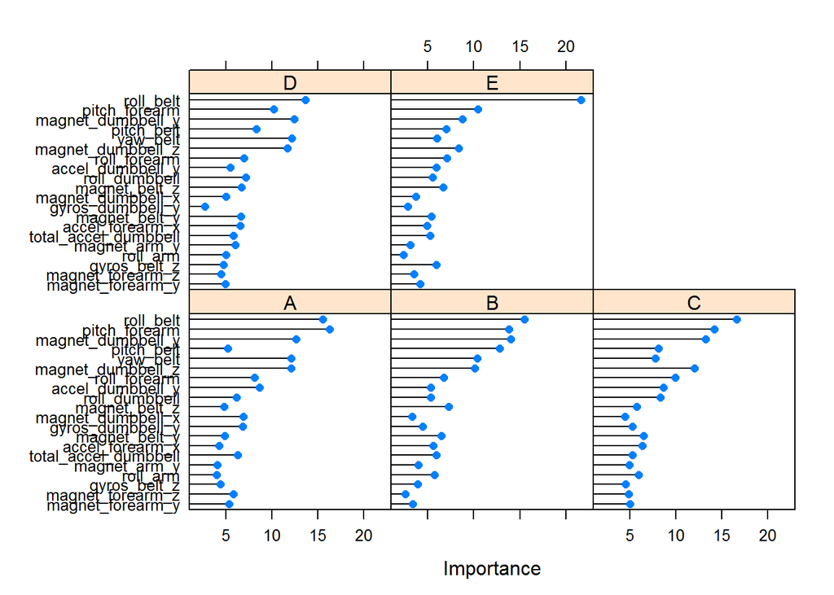

```r
plot(vi, top = 20)
```

```r
print(vi$importance[1:20,])
```

```
##                          A         B          C          D           E
## roll_belt        15.511559 15.508061 16.6327132 13.6704503 21.62280932
## pitch_belt        5.215967 12.827070  8.1405561  8.3352102  6.99999225
## yaw_belt         12.099090 10.360593  7.7683179 12.1574402  6.02101837
## total_accel_belt  3.561781  2.943747  3.2369795  3.6498566  2.98243778
## gyros_belt_x      2.860483  2.149965  3.5100378  3.4902503  2.26160419
## gyros_belt_y      2.779667  2.817085  3.0899654  3.5882726  0.53931765
## gyros_belt_z      4.429240  3.911728  4.5236730  4.7493473  5.95778944
## accel_belt_x      3.644629  3.812017  2.7334498  1.7959780 -0.54678237
## accel_belt_y      2.142457  3.075759  2.6709968  3.6961923  1.59435528
## accel_belt_z      4.824292  4.540394  4.6231943  3.6480007  2.26475668
## magnet_belt_x     2.900625  4.684630  4.8389485  4.1707947  3.08258205
## magnet_belt_y     4.859837  6.466910  6.4770045  6.6228186  5.41585089
## magnet_belt_z     4.781407  7.291626  5.7491264  6.7237484  6.68034741
## roll_arm          3.995279  5.694912  5.9899418  4.9917282  2.36796144
## pitch_arm         2.721384  3.404861  2.6648625  3.2498395 -0.03839386
## yaw_arm           4.877124  2.296978  3.4682634  4.0792867  3.37987628
## total_accel_arm   2.199120  2.790126  0.6433739  2.7782285  1.34651590
## gyros_arm_x       3.902331  1.326391  3.9503570  3.1597669  1.67400173
## gyros_arm_y       3.883626  4.727379  0.6391323  2.0737014  0.44334799
## gyros_arm_z       1.492936  2.365962  1.6592458  0.4341092  1.55034208
```

```r
Imp20 <- rownames(vi$importance[1:20,])
```

### Cross Validation

For cross validation and to estimate the out-of-sample error, I have used the `createDataPartition` function to create balanced splits of the data. Since the y argument to this function is a factor, the random sampling occurs within each class and should preserve the overall class distribution of the data. I have used a 70/30% training/testing split on the `fit.train` data.

```r
library(caret); set.seed(1111)
inTrain <- createDataPartition(y=fit.train$classe, p=0.7, list=FALSE)
trainFit <- fit.train[inTrain,]
testFit <- fit.train[-inTrain,]
```

### Creating the Random Forest Model

I used a random forest algorithm (`rfModel`) to create the prediction model. Due to time contraints, and the lengthy processing time with a large number of obervations in the data, I have decided to use only 100 trees.

```r
library(caret); set.seed(1111)
rfModel <- train(classe ~ ., method = "rf",
                 trainFit[,c(Imp20, "classe")], ntree = 100, importance = TRUE)
```

### Estimating out-of-sample error

As is often the case, the random forest has a prefect accuracy when examining the partition used for training the algorithm, `trainFit`. This is the *in bag* or *in sample* accuracy.

```r
confusionMatrix(trainFit$classe,predict(rfModel,trainFit))$table
```

```
##           Reference
## Prediction    A    B    C    D    E
##          A 3906    0    0    0    0
##          B    0 2658    0    0    0
##          C    0    0 2396    0    0
##          D    0    0    0 2252    0
##          E    0    0    0    0 2525
```

However the algorithm uses bootstrapping to assign a measure of accuracy. The random forest built-in estimate of accuracy from the `caret` package is estimated to be `0.9600245`.

```r
rfModel$results[2,]
```

```
##   mtry  Accuracy    Kappa  AccuracySD     KappaSD
## 2   11 0.9600245 0.949436 0.002654708 0.003357672
```

We can test this estimation of accuracy by using the model `rfModel` to predict from the 30% partition created using the `createDataPartition` function as part of the `caret` package, stored in the `testFit` data frame. This gives us an accuracy of `0.9716228`. marginally better than the OOB error predicted by the `caret` package in built function.

```r
fit.predict <- predict(rfModel,testFit)
confusionMatrix(testFit$classe,fit.predict)
```

```
## Confusion Matrix and Statistics
##
##           Reference
## Prediction    A    B    C    D    E
##          A 1640   16    6   11    1
##          B   21 1098   17    2    1
##          C    4   31  979   11    1
##          D    3    1   21  936    3
##          E    5    0    5    5 1067
##
## Overall Statistics
##
##                Accuracy : 0.972
##                  95% CI : (0.9674, 0.976)
##     No Information Rate : 0.2843
##     P-Value [Acc > NIR] : < 2e-16
##
##                   Kappa : 0.9645
##  Mcnemar's Test P-Value : 0.02904
##
## Statistics by Class:
##
##                      Class: A Class: B Class: C Class: D Class: E
## Sensitivity            0.9803   0.9581   0.9523   0.9699   0.9944
## Specificity            0.9919   0.9913   0.9903   0.9943   0.9969
## Pos Pred Value         0.9797   0.9640   0.9542   0.9710   0.9861
## Neg Pred Value         0.9922   0.9899   0.9899   0.9941   0.9988
## Prevalence             0.2843   0.1947   0.1747   0.1640   0.1823
## Detection Rate         0.2787   0.1866   0.1664   0.1590   0.1813
## Detection Prevalence   0.2845   0.1935   0.1743   0.1638   0.1839
## Balanced Accuracy      0.9861   0.9747   0.9713   0.9821   0.9956
```